# **Panorama da inflação**

Os principais índices de inflação do Brasil, apontam em agosto de 2004 um avanço da inflação de em média **0.80%**. Com esse resultado, no ano a inflação acumula uma variação média positiva de **6.03%**, e em 12 meses uma variação média acumulada de **8.75%**.

[output not shown]

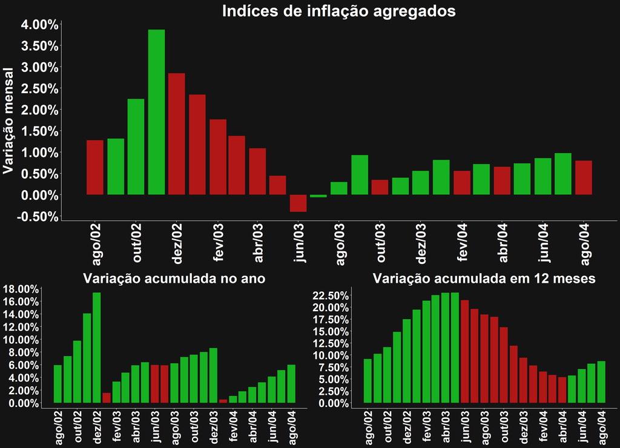

Índices selecionados para a média: IPCA, INPC e IGP-M.

# IPCA

O Indíce de Preços ao Consumidor Amplo (IPCA) variou 0.69% em agosto, valor superior ao mesmo período do ano anterior quando apresentou uma taxa de 0.34%. Com esse resultado o indíce acumula no ano uma variação positiva de 5.14%, e em 12 meses uma variação positiva de 7.18%.

|  | 08/2003 | 07/2004 | 08/2004 |
| --- | --- | --- | --- |
| Variação mensal | 0.34% | 0.91% | 0.69% |
| Variação acumulada no ano | 7.22% | 4.42% | 5.14% |
| Variação acumulada em 12 meses | 15.07% | 6.81% | 7.18% |

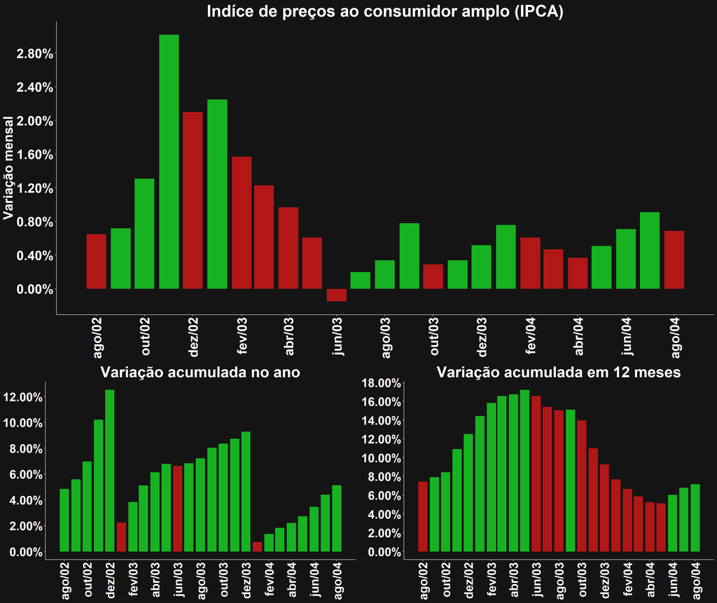

|  | Variação mensal | Variação acumulada no ano | Peso mensal |
| --- | --- | --- | --- |
| Alimentação e bebidas | 0.85% | 3.64% | 23% |
| Habitação | 0.34% | 5.42% | 16.67% |
| Artigos de residência | -0.03% | 3.17% | 5.54% |
| Vestuário | 0.5% | 4.95% | 5.24% |
| Transportes | 1.21% | 5.84% | 21.22% |
| Saúde e cuidados pessoais | 0.42% | 5.74% | 10.57% |
| Despesas pessoais | 0.65% | 4.28% | 9.09% |
| Educação | 0.57% | 9.92% | 4.86% |
| Comunicação | 0.64% | 7.05% | 3.81% |

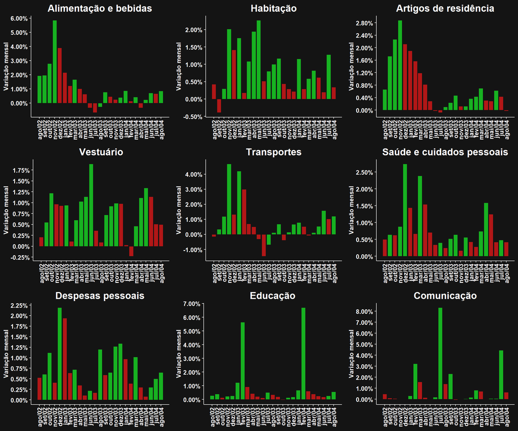

A nível de sub-itens os que mais influenciaram positivamente no resultado em relação ao seu peso foram Etanol (11.49%%) e Gasolina (1.64%%), e negativamente Arroz (-3.36%%) e Feijão - carioca (rajado)) (-9.39%%).

|  | Variação mensal | Variação acumulada no ano | Peso mensal |
| --- | --- | --- | --- |
| Etanol | 11.49% | 7.99% | 0.87% |
| Refeição | 1.89% | 6.46% | 2.38% |
| Gasolina | 1.64% | 5.63% | 4.03% |
| Empregado doméstico | 1.4% | 2.48% | 3% |

|  | Variação mensal | Variação acumulada no ano | Peso mensal |
| --- | --- | --- | --- |
| Gás de botijão | -0.95% | 5.5% | 1.69% |
| Óleo de soja | -2.29% | -0.95% | 0.4% |
| Arroz | -3.36% | -7.54% | 1.01% |
| Feijão - carioca (rajado)) | -9.39% | -1.88% | 0.24% |

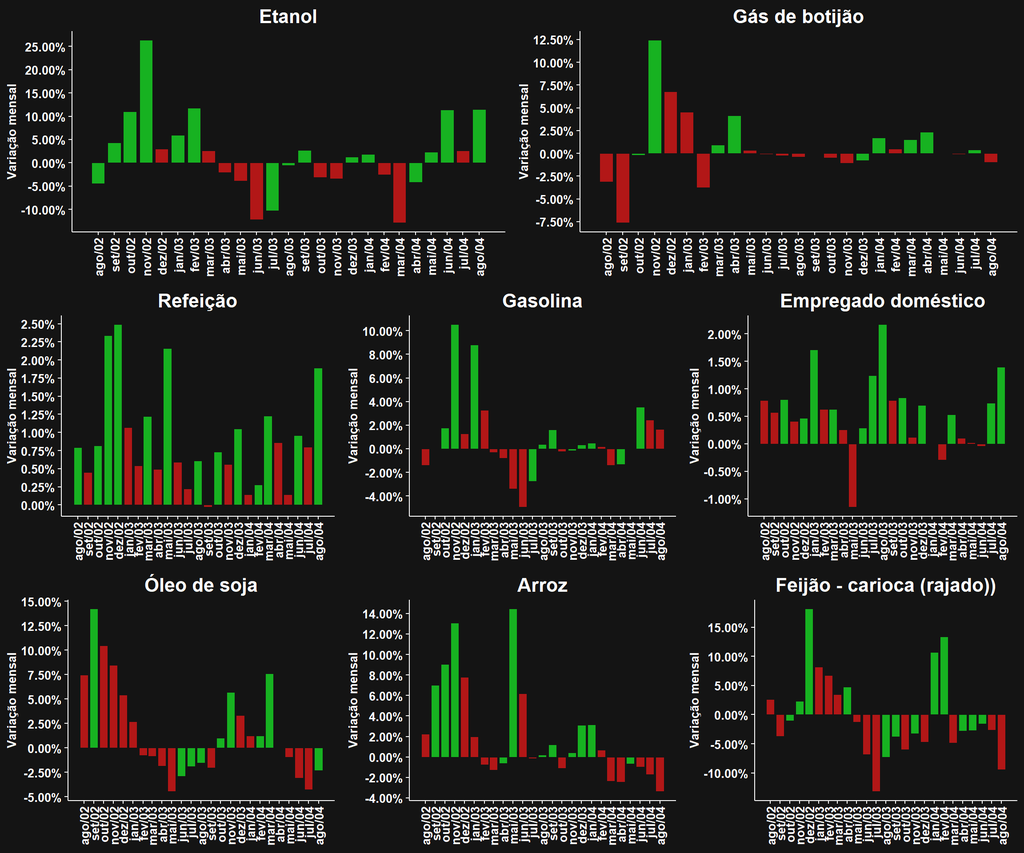

# INPC

O Indíce Nacional de Preços ao Consumidor (INPC) variou 0.5% em agosto, valor superior ao mesmo período do ano anterior quando apresentou uma taxa de 0.18%. Com esse resultado o indíce acumula no ano uma variação positiva de 4.41%, e em 12 meses uma variação positiva de 6.64%.

|  | 08/2003 | 07/2004 | 08/2004 |
| --- | --- | --- | --- |
| Variação mensal | 0.18% | 0.73% | 0.5% |
| Variação acumulada no ano | 8.08% | 3.89% | 4.41% |
| Variação acumulada em 12 meses | 17.53% | 6.3% | 6.64% |

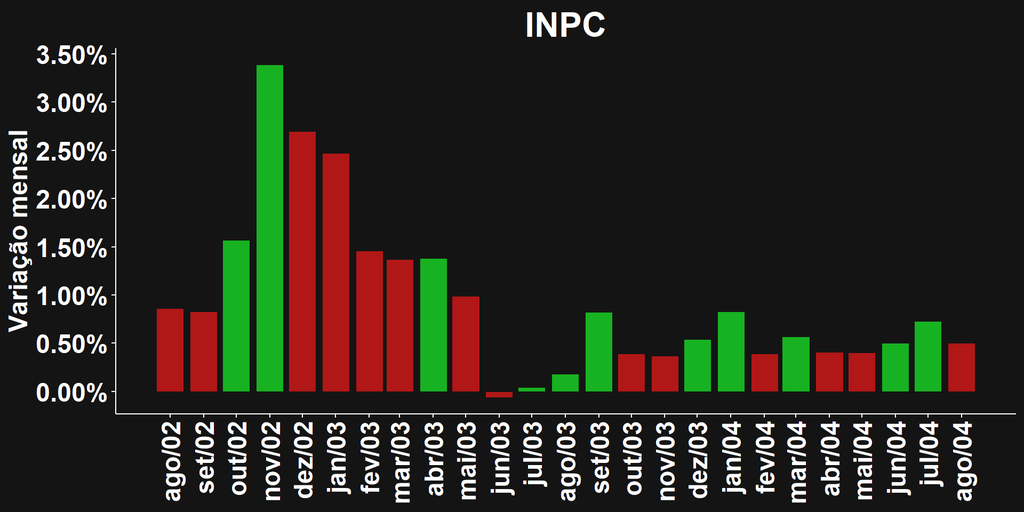

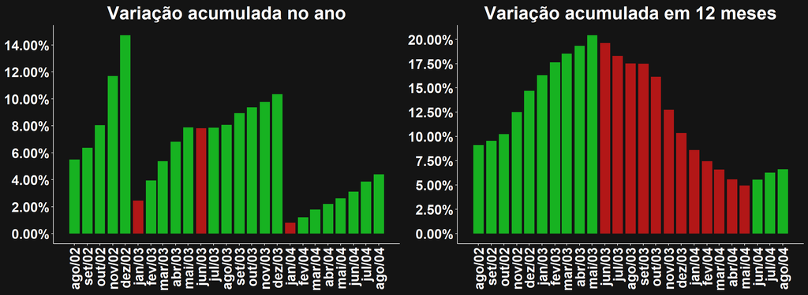

# IGP-M

O Indíce Geral de Preços de Mercado (IGP-M) variou 1.22% em agosto, valor superior ao mesmo período do ano anterior quando apresentou uma taxa de 0.38%. Com esse resultado o indíce acumula no ano uma variação positiva de 8.54%, e em 12 meses uma variação positiva de 12.44%.

|  | 08/2003 | 07/2004 | 08/2004 |
| --- | --- | --- | --- |
| Variação mensal | 0.38% | 1.31% | 1.22% |
| Variação acumulada no ano | 3.45% | 7.24% | 8.54% |
| Variação acumulada em 12 meses | 22.88% | 11.51% | 12.44% |

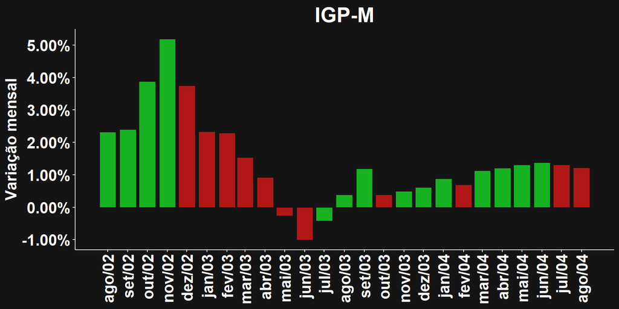

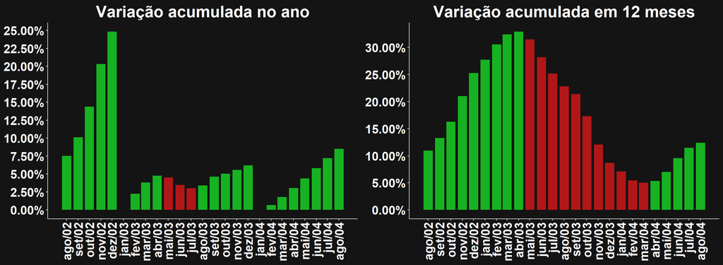

# IGP-DI

O Indíce Geral de Preços - Disponibilidade Interna (IGP-DI) variou 1.31% em agosto, valor superior ao mesmo período do ano anterior quando apresentou uma taxa de 0.62%. Com esse resultado o indíce acumula no ano uma variação positiva de 8.66%, e em 12 meses uma variação positiva de 12.37%.

|  | 08/2003 | 07/2004 | 08/2004 |
| --- | --- | --- | --- |
| Variação mensal | 0.62% | 1.14% | 1.31% |
| Variação acumulada no ano | 2.72% | 7.26% | 8.66% |
| Variação acumulada em 12 meses | 22.03% | 11.6% | 12.37% |

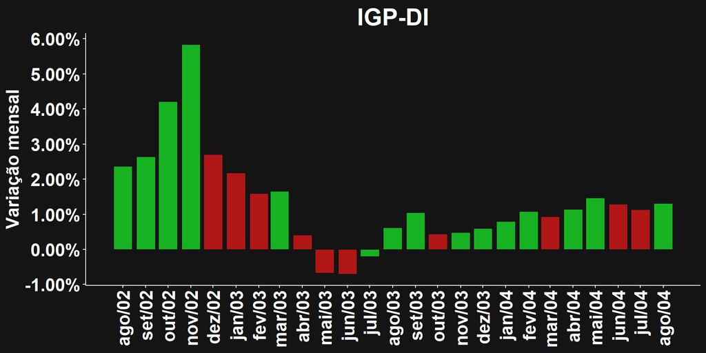

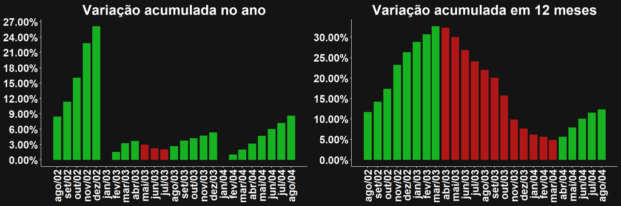

[output not shown]

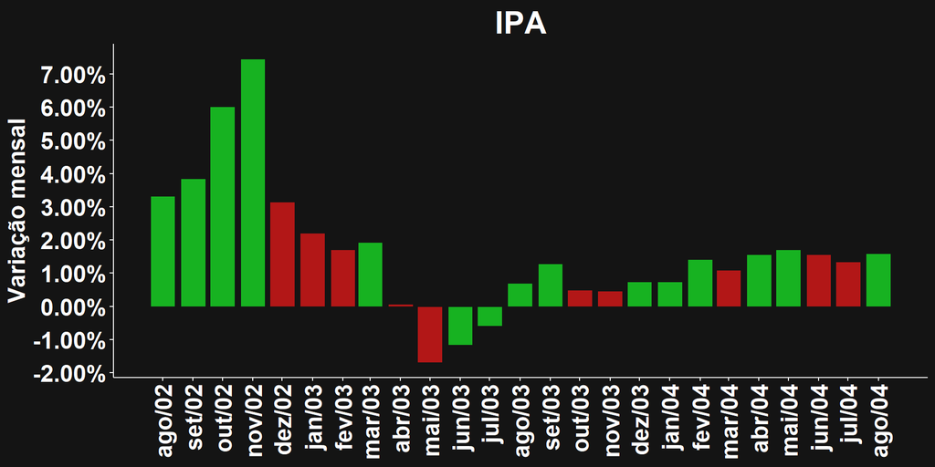

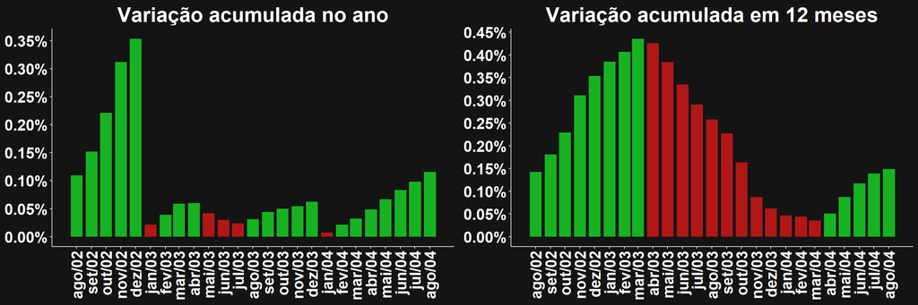

O Indíce de Preços ao Consumidor (IPC), integrante do IGP-DI com peso de 30%, apresentou variação de 0.78% em agosto, valor superior ao mesmo período do ano anterior quando apresentou uma taxa de 0.13%. Com esse resultado o indíce acumula no ano uma variação positiva de 3.98%, e em 12 meses uma variação positiva de 6.94%.

|  | 08/2003 | 07/2004 | 08/2004 |
| --- | --- | --- | --- |
| Variação mensal | 0.13% | 0.59% | 0.78% |
| Variação acumulada no ano | 4.63% | 3.17% | 3.98% |
| Variação acumulada em 12 meses | 14.61% | 6.25% | 6.94% |

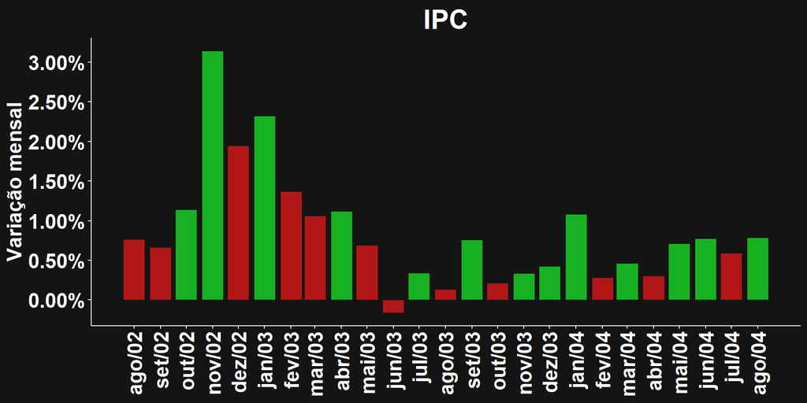

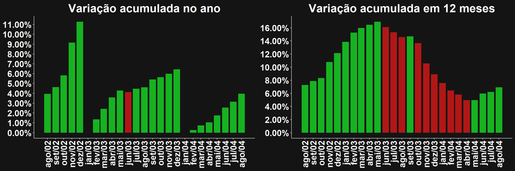

|  | 08/2003 | 07/2004 | 08/2004 |
| --- | --- | --- | --- |
| Variação mensal | 1.44% | 1.12% | 0.81% |
| Variação acumulada no ano | 10.42% | 6.56% | 7.42% |
| Variação acumulada em 12 meses | 18.94% | 10.71% | 10.01% |

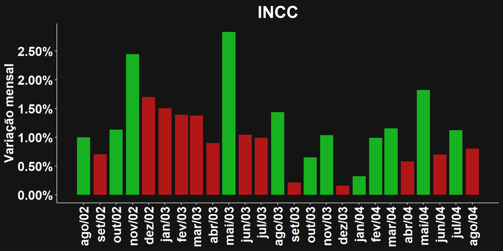

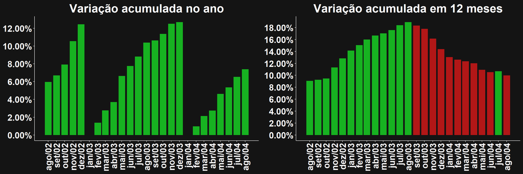

# Estatísticas

As estatísticas descritivas a seguir são feitas com base nos últimos 48 meses, e tem como objetivo possibilitar a avaliação do resultado observado em comparação aos períodos anteriores.

|  | Minimo | 1 Quartil | Mediana | Media | 3 Quartil | Maximo | Desvio Padrão |
| --- | --- | --- | --- | --- | --- | --- | --- |
| IPCA | -0.15% | 0.38% | 0.6% | 0.72% | 0.78% | 3.02% | 0.57% |
| INPC | -0.06% | 0.42% | 0.62% | 0.81% | 0.95% | 3.39% | 0.66% |
| IGP-M | -1% | 0.38% | 0.95% | 1.1% | 1.38% | 5.19% | 1.1% |
| IGP-DI | -0.7% | 0.43% | 0.85% | 1.1% | 1.46% | 5.84% | 1.12% |
| IPA | -1.68% | 0.44% | 1.09% | 1.3% | 1.75% | 7.45% | 1.57% |
| IPC | -0.16% | 0.38% | 0.63% | 0.71% | 0.81% | 3.14% | 0.58% |
| INCC | 0.16% | 0.4% | 0.71% | 0.91% | 1.14% | 2.84% | 0.64% |

Levando em consideração o desvio padrão de cada indíce, proporcionalmente os que mais se afastaram da média foram o INPC, o IGP-DI e o IPA.

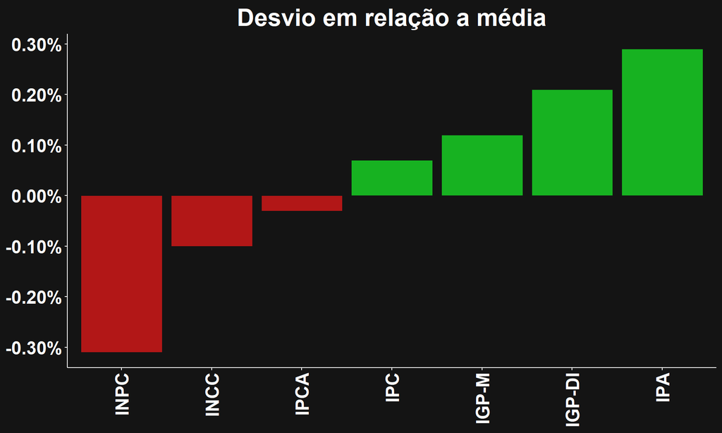

**João Victor Gomes**  
**jvg.santana@gmail.com**  
**[linkedin.com/in/jvictorgomes](https://www.linkedin.com/in/jvictorgomes/)**